# Introduction to Phylogenetics in R

# An introduction to phylogenetic comparative methods in R

This tutorial is intended to get you familiar with the R environment for conducting phylogenetic comparative analyses.

## I. Preparing the R environment

### Installing packages

To install a package directly from CRAN, use:

```r
install.packages("geiger")
install.packages("phytools")
remotes::install_github("uyedaj/treeplyr")
install.packages("rotl")
install.packages("phylolm")
```

Load the package using ‘library’.

```r
library(geiger)
library(phytools)
library(treeplyr)
library(rotl)
library(phylolm)
```

### II. Reading in a tree & tree data structures

There are a number of functions to read in phylogenetic tree data into R. We are going to use as our example tree phylogeny of Muroid rodents (Schenk, Rowe & Steppan, 2013; Systematic Biology). The tree can be downloaded from my github site, or it be accessed directly from treebase (submission 12303).

```r
tree <- read.tree("../data/schenk.tre")
tree
```

```
##
## Phylogenetic tree with 305 tips and 304 internal nodes.
##
## Tip labels:
##   Eliomys_quercinus, Sciurus_sp., Sicista_tianshanica, Napaeozapus_insignis, Zapus_princeps, Allactaga_sibirica, ...
##
## Rooted; includes branch lengths.
```

We can plot the tree:

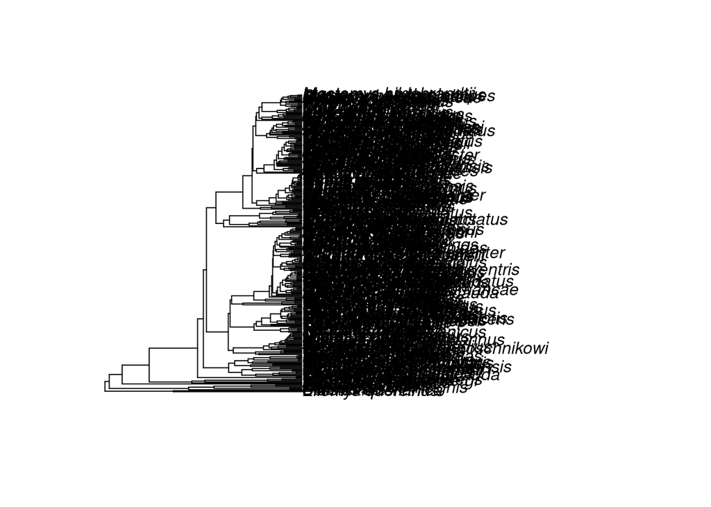

```r
plot(tree)
```

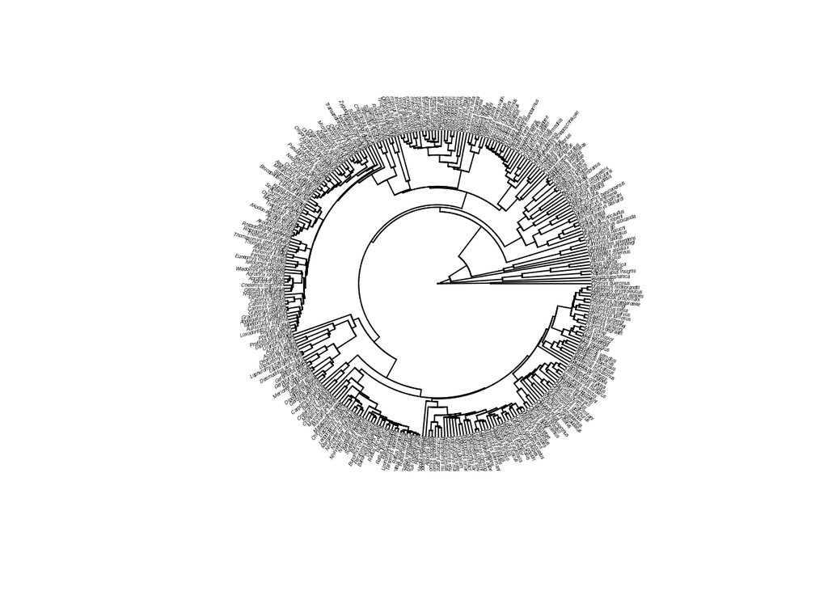

```r
plot(tree, type="fan", cex=0.25)
```

You may notice that the help file for `plot` is not very helpful for options for phylogenies:

```r
?plot
```

```
## Help on topic 'plot' was found in the following packages:
##
##   Package               Library
##   base                  /usr/lib/R/library
##   graphics              /usr/lib/R/library
##
##
## Using the first match ...
```

This is because `plot` is a “method” that behaves differently on objects of different classes.

```r
plot
```

```
## function (x, y, ...)
## UseMethod("plot")
## <bytecode: 0x5602ffab9ca0>
## <environment: namespace:base>
```

```r
methods(plot)
```

```
##  [1] plot.acf*                 plot.ACF*
##  [3] plot.anc.Bayes            plot.ancThresh*
##  [5] plot.augPred*             plot.auteurMCMC*
##  [7] plot.auteurMCMCMC*        plot.backbonePhylo*
##  [9] plot.changesMap           plot.codonTest*
## [11] plot.cohesiveBlocks*      plot.communities*
## [13] plot.compareFits*         plot.contMap
## [15] plot.cophylo              plot.correlogram*
## [17] plot.correlogramList*     plot.correspondence*
## [19] plot.cospeciation*        plot.ctt*
## [21] plot.data.frame*          plot.decomposed.ts*
## [23] plot.default              plot.dendrogram*
## [25] plot.density*             plot.density.mcmcMk*
## [27] plot.density.threshBayes* plot.densityMap
## [29] plot.describe.simmap*     plot.deSolve*
## [31] plot.ecdf                 plot.edge.widthMap
## [33] plot.evonet               plot.expand.clade*
## [35] plot.factor*              plot.fitBayes*
## [37] plot.fitHRM*              plot.fitMk
## [39] plot.fitPagel             plot.fitpolyMk*
## [41] plot.formula*             plot.function
## [43] plot.gfit                 plot.gls*
## [45] plot.gtt*                 plot.hclust*
## [47] plot.histogram*           plot.HoltWinters*
## [49] plot.igraph*              plot.intervals.lmList*
##  [ reached getOption("max.print") -- omitted 80 entries ]
## see '?methods' for accessing help and source code
```

```r
class(tree)
```

```
## [1] "phylo"
```

```r
?plot.phylo
```

How is a tree stored? How can it be manipulated and modified? A tree object in R is a data structure called a “list”, and given a special class, called a “phylo” object. It will be worth your time getting familiar with [data structures in R](http://adv-r.had.co.nz/Data-structures.html).

`str` is a useful commands for determining what is in an R object:

```r
str(tree)
```

```
## List of 4
##  $ edge       : int [1:608, 1:2] 306 307 307 306 308 309 309 310 311 311 ...
##  $ edge.length: num [1:608] 16.45 30.95 30.95 1.04 19.12 ...
##  $ Nnode      : int 304
##  $ tip.label  : chr [1:305] "Eliomys_quercinus" "Sciurus_sp." "Sicista_tianshanica" "Napaeozapus_insignis" ...
##  - attr(*, "class")= chr "phylo"
##  - attr(*, "order")= chr "cladewise"
```

Each element of the list can be accessed by multiple means:

```r
tree['tip.label']
```

```
## $tip.label
##  [1] "Eliomys_quercinus"            "Sciurus_sp."
##  [3] "Sicista_tianshanica"          "Napaeozapus_insignis"
##  [5] "Zapus_princeps"               "Allactaga_sibirica"
##  [7] "Dipus_sagitta"                "Jaculus_jaculus"
##  [9] "Typhlomys_cinereus"           "Myospalax_aspalax"
## [11] "Nanospalax_ehrenbergi"        "Tachyoryctes_splendens"
## [13] "Cannomys_badius"              "Rhizomys_pruinosus"
## [15] "Calomyscus_baluchi"           "Calomyscus_sp"
## [17] "Brachytarsomys_albicauda"     "Gymnuromys_roberti"
## [19] "Voalavo_gymnocaudus"          "Eliurus_minor"
## [21] "Eliurus_tanala"               "Macrotarsomys_bastardi"
## [23] "Monticolomys_koopmani"        "Hypogeomys_antimena"
## [25] "Brachyuromys_betsileoensis"   "Nesomys_rufus"
## [27] "Delanymys_brooksi"            "Mystromys_albicaudatus"
## [29] "Petromyscus_monticularis"     "Saccostomus_campestris"
## [31] "Beamys_hindei"                "Cricetomys_gambianus"
## [33] "Steatomys_krebsi"             "Steatomys_parvus"
## [35] "Malacothrix_typica"           "Dendromus_nyasae"
## [37] "Dendromus_insignis"           "Dendromus_mesomelas"
## [39] "Mesocricetus_auratus"         "Phodopus_sungorus"
## [41] "Cricetulus_griseus"           "Cricetulus_migratorius"
## [43] "Cricetus_cricetus"            "Prometheomys_schaposchnikowi"
## [45] "Ondatra_zibethicus"           "Phenacomys_intermedius"
## [47] "Lemmus_sibiricus"             "Synaptomys_cooperi"
## [49] "Clethrionomys_gapperi"        "Chionomys_nivalis"
##  [ reached getOption("max.print") -- omitted 255 entries ]
```

```r
tree[['tip.label']]
```

```
##  [1] "Eliomys_quercinus"            "Sciurus_sp."
##  [3] "Sicista_tianshanica"          "Napaeozapus_insignis"
##  [5] "Zapus_princeps"               "Allactaga_sibirica"
##  [7] "Dipus_sagitta"                "Jaculus_jaculus"
##  [9] "Typhlomys_cinereus"           "Myospalax_aspalax"
## [11] "Nanospalax_ehrenbergi"        "Tachyoryctes_splendens"
## [13] "Cannomys_badius"              "Rhizomys_pruinosus"
## [15] "Calomyscus_baluchi"           "Calomyscus_sp"
## [17] "Brachytarsomys_albicauda"     "Gymnuromys_roberti"
## [19] "Voalavo_gymnocaudus"          "Eliurus_minor"
## [21] "Eliurus_tanala"               "Macrotarsomys_bastardi"
## [23] "Monticolomys_koopmani"        "Hypogeomys_antimena"
## [25] "Brachyuromys_betsileoensis"   "Nesomys_rufus"
## [27] "Delanymys_brooksi"            "Mystromys_albicaudatus"
## [29] "Petromyscus_monticularis"     "Saccostomus_campestris"
## [31] "Beamys_hindei"                "Cricetomys_gambianus"
## [33] "Steatomys_krebsi"             "Steatomys_parvus"
## [35] "Malacothrix_typica"           "Dendromus_nyasae"
## [37] "Dendromus_insignis"           "Dendromus_mesomelas"
## [39] "Mesocricetus_auratus"         "Phodopus_sungorus"
## [41] "Cricetulus_griseus"           "Cricetulus_migratorius"
## [43] "Cricetus_cricetus"            "Prometheomys_schaposchnikowi"
## [45] "Ondatra_zibethicus"           "Phenacomys_intermedius"
## [47] "Lemmus_sibiricus"             "Synaptomys_cooperi"
## [49] "Clethrionomys_gapperi"        "Chionomys_nivalis"
##  [ reached getOption("max.print") -- omitted 255 entries ]
```

```r
tree[[3]]
```

```
## [1] 304
```

```r
tree$tip.label
```

```
##  [1] "Eliomys_quercinus"            "Sciurus_sp."
##  [3] "Sicista_tianshanica"          "Napaeozapus_insignis"
##  [5] "Zapus_princeps"               "Allactaga_sibirica"
##  [7] "Dipus_sagitta"                "Jaculus_jaculus"
##  [9] "Typhlomys_cinereus"           "Myospalax_aspalax"
## [11] "Nanospalax_ehrenbergi"        "Tachyoryctes_splendens"
## [13] "Cannomys_badius"              "Rhizomys_pruinosus"
## [15] "Calomyscus_baluchi"           "Calomyscus_sp"
## [17] "Brachytarsomys_albicauda"     "Gymnuromys_roberti"
## [19] "Voalavo_gymnocaudus"          "Eliurus_minor"
## [21] "Eliurus_tanala"               "Macrotarsomys_bastardi"
## [23] "Monticolomys_koopmani"        "Hypogeomys_antimena"
## [25] "Brachyuromys_betsileoensis"   "Nesomys_rufus"
## [27] "Delanymys_brooksi"            "Mystromys_albicaudatus"
## [29] "Petromyscus_monticularis"     "Saccostomus_campestris"
## [31] "Beamys_hindei"                "Cricetomys_gambianus"
## [33] "Steatomys_krebsi"             "Steatomys_parvus"
## [35] "Malacothrix_typica"           "Dendromus_nyasae"
## [37] "Dendromus_insignis"           "Dendromus_mesomelas"
## [39] "Mesocricetus_auratus"         "Phodopus_sungorus"
## [41] "Cricetulus_griseus"           "Cricetulus_migratorius"
## [43] "Cricetus_cricetus"            "Prometheomys_schaposchnikowi"
## [45] "Ondatra_zibethicus"           "Phenacomys_intermedius"
## [47] "Lemmus_sibiricus"             "Synaptomys_cooperi"
## [49] "Clethrionomys_gapperi"        "Chionomys_nivalis"
##  [ reached getOption("max.print") -- omitted 255 entries ]
```

The structure of the tree is stored in the edge matrix:

```r
tree$edge
```

```
##        [,1] [,2]
##   [1,]  306  307
##   [2,]  307    1
##   [3,]  307    2
##   [4,]  306  308
##   [5,]  308  309
##   [6,]  309    3
##   [7,]  309  310
##   [8,]  310  311
##   [9,]  311    4
##  [10,]  311    5
##  [11,]  310  312
##  [12,]  312    6
##  [13,]  312  313
##  [14,]  313    7
##  [15,]  313    8
##  [16,]  308  314
##  [17,]  314    9
##  [18,]  314  315
##  [19,]  315  316
##  [20,]  316   10
##  [21,]  316  317
##  [22,]  317   11
##  [23,]  317  318
##  [24,]  318   12
##  [25,]  318  319
##  [ reached getOption("max.print") -- omitted 583 rows ]
```

And branch lengths are stored in the list element `edge.length`

```r
tree$edge.length
```

```
##  [1] 16.454920 30.951218 30.951218  1.036558 19.122934 27.246646  6.098144
##  [8] 18.255843  2.892659  2.892659  8.926983 12.221519  5.945134  6.276385
## [15]  6.276385  3.101443 43.268137  6.507266 10.276527 26.484344  3.141303
## [22] 23.343042 15.076585  8.266457  3.502364  4.764093  4.764093 11.663253
## [29] 23.784354  1.313264  1.313264  1.392402  6.091229  3.173725  3.347564
## [36] 11.092697  4.133406  6.959292  1.505509  5.453783  4.094128  1.359655
## [43]  1.359655  2.496259  9.647273  2.296729  2.296729  4.258825  7.685177
## [50]  2.595582
##  [ reached getOption("max.print") -- omitted 558 entries ]
```

Tips can be dropped with the function `drop.tip`:

```r
#tree before:
tree
```

```
##
## Phylogenetic tree with 305 tips and 304 internal nodes.
##
## Tip labels:
##   Eliomys_quercinus, Sciurus_sp., Sicista_tianshanica, Napaeozapus_insignis, Zapus_princeps, Allactaga_sibirica, ...
##
## Rooted; includes branch lengths.
```

```r
#tree after dropping two species:
drop.tip(tree, c("Eliomys_quercinus", "Sicista_tianshanica"))
```

```
##
## Phylogenetic tree with 303 tips and 302 internal nodes.
##
## Tip labels:
##   Sciurus_sp., Napaeozapus_insignis, Zapus_princeps, Allactaga_sibirica, Dipus_sagitta, Jaculus_jaculus, ...
##
## Rooted; includes branch lengths.
```

### III. Matching a tree with a dataset

```r
pantheria <- read.csv("../data/pantheria.csv")
rownames(pantheria) <- gsub(" ", "_", pantheria$MSW05_Binomial)
head(pantheria)
```

|  | X | MSW05_Order | MSW05_Family | MSW05_Genus | MSW05_Species | MSW05_Binomial | X1.1_ActivityCycle | X5.1_AdultBodyMass_g | X8.1_AdultForearmLen_mm | X13.1_AdultHeadBodyLen_mm | X2.1_AgeatEyeOpening_d | X3.1_AgeatFirstBirth_d | X18.1_BasalMetRate_mLO2hr | X5.2_BasalMetRateMass_g | X6.1_DietBreadth | X7.1_DispersalAge_d | X9.1_GestationLen_d | X12.1_HabitatBreadth | X22.1_HomeRange_km2 | X22.2_HomeRange_Indiv_km2 | X14.1_InterbirthInterval_d | X15.1_LitterSize | X16.1_LittersPerYear | X17.1_MaxLongevity_m | X5.3_NeonateBodyMass_g | X13.2_NeonateHeadBodyLen_mm | X21.1_PopulationDensity_n.km2 | X10.1_PopulationGrpSize | X23.1_SexualMaturityAge_d | … |
| --- | --- | --- | --- | --- | --- | --- | --- | --- | --- | --- | --- | --- | --- | --- | --- | --- | --- | --- | --- | --- | --- | --- | --- | --- | --- | --- | --- | --- | --- | --- |
| Camelus_dromedarius | 1 | Artiodactyla | Camelidae | Camelus | dromedarius | Camelus dromedarius | 3 | 492714.47 | -999 | -999.00 | -999.00 | 1651.62 | 40293.0 | 407000 | 3 | -999.00 | 386.51 | 1 | 196.32 | -999.00 | 614.41 | 0.98 | 1 | 480.0 | 36751.19 | -999 | 0.98 | 11 | 1947.94 | … |
| Canis_adustus | 2 | Carnivora | Canidae | Canis | adustus | Canis adustus | 1 | 10392.49 | -999 | 745.32 | -999.00 | -999.00 | -999.0 | -999 | 6 | 329.99 | 65.00 | 1 | 1.01 | 1.01 | -999.00 | 4.50 | -999 | 137.0 | -999.00 | -999 | 0.74 | -999 | 249.88 | … |
| Canis_aureus | 3 | Carnivora | Canidae | Canis | aureus | Canis aureus | 2 | 9658.70 | -999 | 827.53 | 7.50 | -999.00 | -999.0 | -999 | 6 | -999.00 | 61.24 | 1 | 2.95 | 3.13 | 365.00 | 3.74 | -999 | 192.0 | 211.82 | -999 | 0.22 | -999 | 371.23 | … |
| Canis_latrans | 4 | Carnivora | Canidae | Canis | latrans | Canis latrans | 2 | 11989.10 | -999 | 872.39 | 11.94 | 365.00 | 3699.0 | 10450 | 1 | 255.00 | 61.74 | 1 | 18.88 | 19.91 | 365.00 | 5.72 | -999 | 262.0 | 200.01 | -999 | 0.25 | -999 | 372.90 | … |
| Canis_lupus | 5 | Carnivora | Canidae | Canis | lupus | Canis lupus | 2 | 31756.51 | -999 | 1055.00 | 14.01 | 547.50 | 11254.2 | 33100 | 1 | 180.00 | 63.50 | 1 | 159.86 | 43.13 | 365.00 | 4.98 | 2 | 354.0 | 412.31 | -999 | 0.01 | -999 | 679.37 | … |
| Bos_frontalis | 6 | Artiodactyla | Bovidae | Bos | frontalis | Bos frontalis | 2 | 800143.05 | -999 | 2700.00 | -999.00 | -999.00 | -999.0 | -999 | 3 | -999.00 | 273.75 | -999 | -999.00 | -999.00 | 403.02 | 1.22 | 1 | 314.4 | 22977.05 | -999 | 0.54 | -999 | 610.97 | … |

```r
td <- make.treedata(tree, pantheria)
td
```

```
## $phy
##
## Phylogenetic tree with 282 tips and 281 internal nodes.
##
## Tip labels:
##   Eliomys_quercinus, Sicista_tianshanica, Napaeozapus_insignis, Zapus_princeps, Allactaga_sibirica, Dipus_sagitta, ...
##
## Rooted; includes branch lengths.
##
## $dat
## # A tibble: 282 × 56
##        X MSW05…¹ MSW05…² MSW05…³ MSW05…⁴ MSW05…⁵ X1.1_…⁶ X5.1_…⁷ X8.1_…⁸ X13.1…⁹
##    <int> <fct>   <fct>   <fct>   <fct>   <fct>     <int>   <dbl>   <dbl>   <dbl>
##  1   512 Rodent… Glirid… Eliomys querci… Eliomy…       1   115.     -999   139.
##  2  4416 Rodent… Dipodi… Sicista tiansh… Sicist…    -999  -999      -999  -999
##  3  2862 Rodent… Dipodi… Napaeo… insign… Napaeo…       1    22.2    -999    89.7
##  4  5403 Rodent… Dipodi… Zapus   prince… Zapus …    -999    27.2    -999    94.1
##  5  4949 Rodent… Dipodi… Allact… sibiri… Allact…    -999  -999      -999  -999
##  6  1213 Rodent… Dipodi… Dipus   sagitta Dipus …    -999    89      -999  -999
##  7  1568 Rodent… Dipodi… Jaculus jaculus Jaculu…    -999    59.8    -999   102.
##  8  5309 Rodent… Platac… Typhlo… cinere… Typhlo…    -999  -999      -999  -999
##  9  2770 Rodent… Spalac… Myospa… aspalax Myospa…    -999  -999      -999  -999
## 10  4791 Rodent… Spalac… Tachyo… splend… Tachyo…    -999   227.     -999   198.
## # … with 272 more rows, 46 more variables: X2.1_AgeatEyeOpening_d <dbl>,
## #   X3.1_AgeatFirstBirth_d <dbl>, X18.1_BasalMetRate_mLO2hr <dbl>,
## #   X5.2_BasalMetRateMass_g <dbl>, X6.1_DietBreadth <int>,
## #   X7.1_DispersalAge_d <dbl>, X9.1_GestationLen_d <dbl>,
## #   X12.1_HabitatBreadth <int>, X22.1_HomeRange_km2 <dbl>,
## #   X22.2_HomeRange_Indiv_km2 <dbl>, X14.1_InterbirthInterval_d <dbl>,
## #   X15.1_LitterSize <dbl>, X16.1_LittersPerYear <dbl>, …
## # ℹ Use `print(n = ...)` to see more rows, and `colnames()` to see all variable names
```

```r
attributes(td)$dropped
```

```
## $dropped_from_tree
##  [1] "Camelus_dromedarius"     "Canis_adustus"
##  [3] "Canis_aureus"            "Canis_latrans"
##  [5] "Canis_lupus"             "Bos_frontalis"
##  [7] "Bos_grunniens"           "Bos_javanicus"
##  [9] "Callicebus_cupreus"      "Callicebus_discolor"
## [11] "Callicebus_donacophilus" "Callicebus_dubius"
## [13] "Callicebus_hoffmannsi"   "Callicebus_lucifer"
## [15] "Callicebus_lugens"       "Callicebus_medemi"
## [17] "Callicebus_melanochir"   "Callicebus_modestus"
## [19] "Caluromys_derbianus"     "Caluromys_lanatus"
## [21] "Caluromys_philander"     "Caluromysiops_irrupta"
## [23] "Calyptophractus_retusus" "Camelus_bactrianus"
## [25] "Bos_sauveli"             "Bos_taurus"
## [27] "Boselaphus_tragocamelus" "Brachiones_przewalskii"
```

[output cut: 26 more lines]

```r
colnames(td$dat)
```

```
##  [1] "X"                             "MSW05_Order"
##  [3] "MSW05_Family"                  "MSW05_Genus"
##  [5] "MSW05_Species"                 "MSW05_Binomial"
##  [7] "X1.1_ActivityCycle"            "X5.1_AdultBodyMass_g"
##  [9] "X8.1_AdultForearmLen_mm"       "X13.1_AdultHeadBodyLen_mm"
## [11] "X2.1_AgeatEyeOpening_d"        "X3.1_AgeatFirstBirth_d"
## [13] "X18.1_BasalMetRate_mLO2hr"     "X5.2_BasalMetRateMass_g"
## [15] "X6.1_DietBreadth"              "X7.1_DispersalAge_d"
## [17] "X9.1_GestationLen_d"           "X12.1_HabitatBreadth"
## [19] "X22.1_HomeRange_km2"           "X22.2_HomeRange_Indiv_km2"
## [21] "X14.1_InterbirthInterval_d"    "X15.1_LitterSize"
## [23] "X16.1_LittersPerYear"          "X17.1_MaxLongevity_m"
## [25] "X5.3_NeonateBodyMass_g"        "X13.2_NeonateHeadBodyLen_mm"
## [27] "X21.1_PopulationDensity_n.km2" "X10.1_PopulationGrpSize"
## [29] "X23.1_SexualMaturityAge_d"     "X10.2_SocialGrpSize"
## [31] "X24.1_TeatNumber"              "X12.2_Terrestriality"
## [33] "X6.2_TrophicLevel"             "X25.1_WeaningAge_d"
## [35] "X5.4_WeaningBodyMass_g"        "X13.3_WeaningHeadBodyLen_mm"
## [37] "References"                    "X5.5_AdultBodyMass_g_EXT"
## [39] "X16.2_LittersPerYear_EXT"      "X5.6_NeonateBodyMass_g_EXT"
## [41] "X5.7_WeaningBodyMass_g_EXT"    "X26.1_GR_Area_km2"
## [43] "X26.2_GR_MaxLat_dd"            "X26.3_GR_MinLat_dd"
## [45] "X26.4_GR_MidRangeLat_dd"       "X26.5_GR_MaxLong_dd"
## [47] "X26.6_GR_MinLong_dd"           "X26.7_GR_MidRangeLong_dd"
## [49] "X27.1_HuPopDen_Min_n.km2"      "X27.2_HuPopDen_Mean_n.km2"
##  [ reached getOption("max.print") -- omitted 6 entries ]
```

```r
td2 <- mutate(td, lnMass = log(X5.1_AdultBodyMass_g),lnBMR = log(X18.1_BasalMetRate_mLO2hr), desert=ifelse(X28.1_Precip_Mean_mm < 21, 1, 0)) %>% filter(., !is.na(lnMass), !is.na(lnBMR)) %>% select(., lnMass, lnBMR, desert)
td2
```

```
## $phy
##
## Phylogenetic tree with 63 tips and 62 internal nodes.
##
## Tip labels:
##   Napaeozapus_insignis, Jaculus_jaculus, Tachyoryctes_splendens, Cannomys_badius, Mystromys_albicaudatus, Saccostomus_campestris, ...
##
## Rooted; includes branch lengths.
##
## $dat
## # A tibble: 63 × 3
##    lnMass lnBMR desert
##     <dbl> <dbl>  <dbl>
##  1   3.10  3.68      0
##  2   4.09  4.52      1
##  3   5.43  5.04      0
##  4   6.16  5.15      0
##  5   4.46  4.84      0
##  6   3.92  3.94      0
##  7   7.14  6.93      1
##  8   2.83  3.03      0
##  9   3.42  4.33      0
## 10   6.06  5.45      0
## # … with 53 more rows
## # ℹ Use `print(n = ...)` to see more rows
```

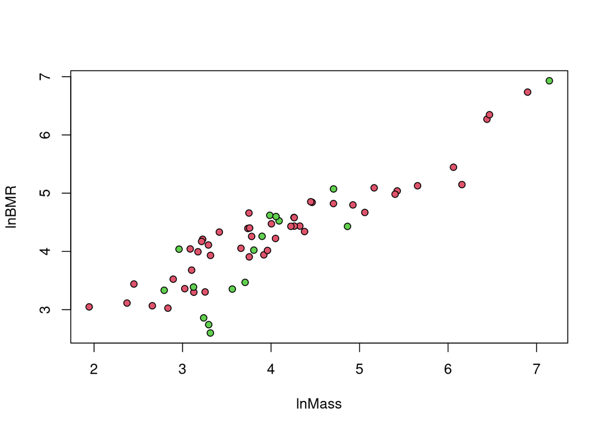

```r
plot(td2[['lnMass']], td2[['lnBMR']], pch=21, bg=td2[['desert']]+2, xlab="lnMass", ylab="lnBMR")
```

## IV. Visualization

We can visualize the distribution of the data on the tree using a “traitgram”:

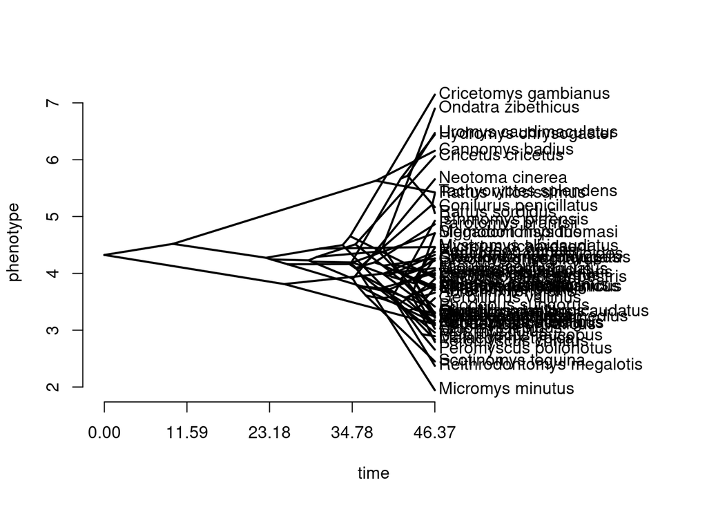

```r
phenogram(td2$phy, td2[['lnMass']], spread.labels=FALSE)
```

We can also calculate the node contrasts (standardized differences) to see where the big changes are on the tree:

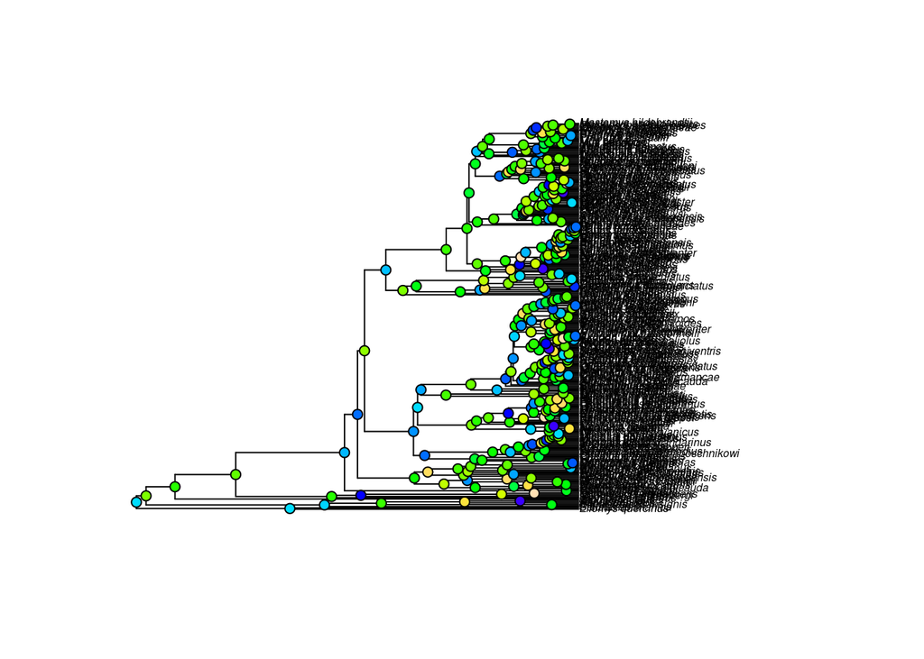

```r
picMass <- pic(td2[['lnMass']], td2$phy)
plot(tree, cex=0.5)
nodelabels(pch=21, bg=topo.colors(100)[round((picMass-min(picMass))/diff(range(picMass))*100,0)])
```

Phytools’ scattergram can be useful for exploring correlations between traits across the phylogeny:

```r
fancyDat <- as.matrix(td2$dat[1:3])
rownames(fancyDat) <- td2$phy$tip.label
fancyTree(td2$phy, type="scattergram", X=fancyDat, fsize=0.3)
```

```
## Computing multidimensional phylogenetic scatterplot matrix...
```

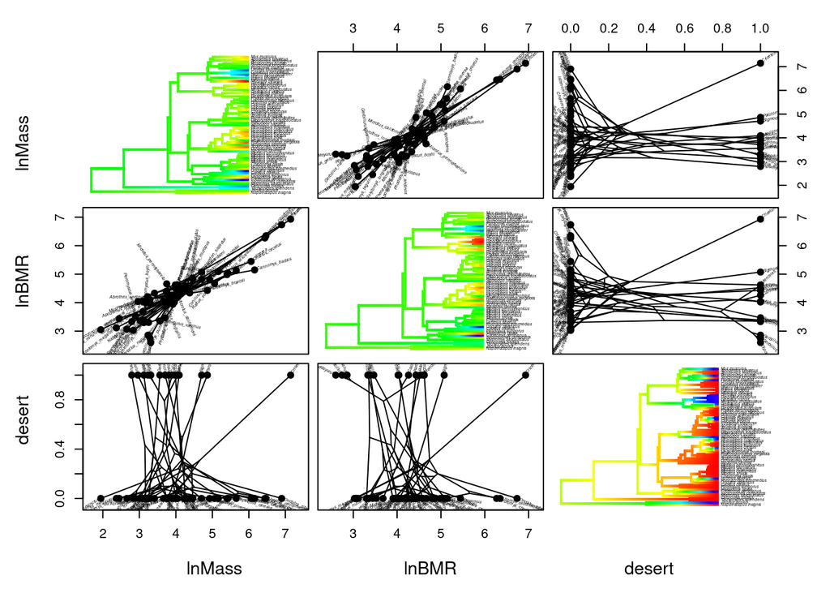

## V. Simple analyses of traits

### Discrete trait models

We generally use “continuous-time Markov models” to model discrete traits on the phylogeny. These models are used to model transitions between discrete character states, whether they are the presence/absence of phenotypic trait or nucleotide in a sequence of DNA. We can fit such a model to a trait and a phylogeny and then draw a possible reconstructed history of the trait under the model, which is called ancestral state reconstruction. Here we make “stochastic character maps”, which are draws from the posterior distribution of ancestral state reconstructions under the model. This illustrates how uncertain ancestral state reconstruction is!

```r
tdDiscrete <- filter(td2, !is.na(desert)) %>% mutate(., desert2=desert+1)
simmap <- make.simmap(tdDiscrete$phy, tdDiscrete[['desert2']], model="ER", nsim=9)
```

```
## make.simmap is sampling character histories conditioned on
## the transition matrix
##
## Q =
##             1           2
## 1 -0.03457468  0.03457468
## 2  0.03457468 -0.03457468
## (estimated using likelihood);
## and (mean) root node prior probabilities
## pi =
##   1   2
## 0.5 0.5
```

```
## Done.
```

```
## no colors provided. using the following legend:
##         1         2
##   "black" "#DF536B"
```

```
## no colors provided. using the following legend:
##         1         2
##   "black" "#DF536B"
```

```
## no colors provided. using the following legend:
##         1         2
##   "black" "#DF536B"
```

```
## no colors provided. using the following legend:
##         1         2
##   "black" "#DF536B"
```

```
## no colors provided. using the following legend:
##         1         2
##   "black" "#DF536B"
```

```
## no colors provided. using the following legend:
##         1         2
##   "black" "#DF536B"
```

```
## no colors provided. using the following legend:
##         1         2
##   "black" "#DF536B"
```

```
## no colors provided. using the following legend:
##         1         2
##   "black" "#DF536B"
```

```
## no colors provided. using the following legend:
##         1         2
##   "black" "#DF536B"
```

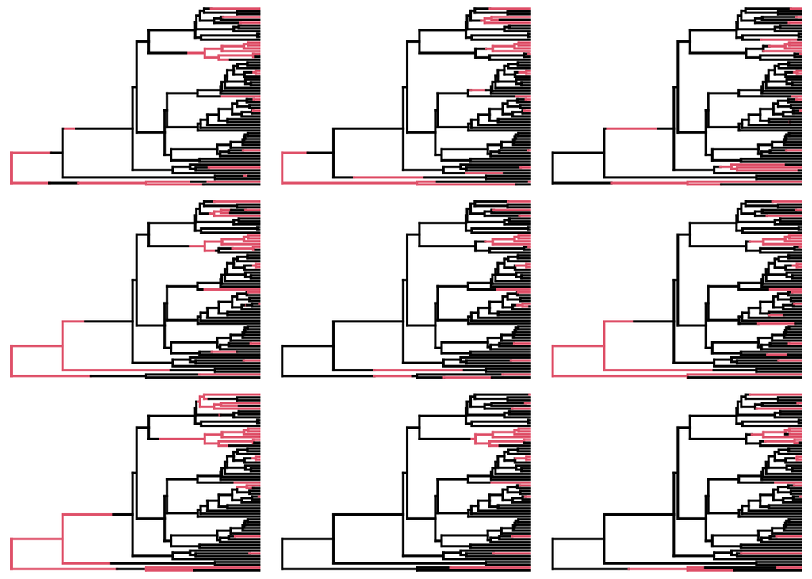

```r
par(mfrow=c(3,3), mar=c(0,0,0,0))
for(i in 1:9){
  plot(simmap[[i]], ftype="off")
}
```

We assumed in the previous model that transitions in and out of desert habitats happened at equal frequency. If we relax this assumption and allow these to be asymmetric, we can see that rodents move out of desert habitats at 3 times the rate they move in. This will change the reconstructed histories!

```r
simmap <- make.simmap(tdDiscrete$phy, tdDiscrete[['desert2']], model="ARD", nsim=9)
```

```
## make.simmap is sampling character histories conditioned on
## the transition matrix
##
## Q =
##             1           2
## 1 -0.05245168  0.05245168
## 2  0.14972520 -0.14972520
## (estimated using likelihood);
## and (mean) root node prior probabilities
## pi =
##   1   2
## 0.5 0.5
```

```
## Done.
```

```
## no colors provided. using the following legend:
##         1         2
##   "black" "#DF536B"
```

```
## no colors provided. using the following legend:
##         1         2
##   "black" "#DF536B"
```

```
## no colors provided. using the following legend:
##         1         2
##   "black" "#DF536B"
```

```
## no colors provided. using the following legend:
##         1         2
##   "black" "#DF536B"
```

```
## no colors provided. using the following legend:
##         1         2
##   "black" "#DF536B"
```

```
## no colors provided. using the following legend:
##         1         2
##   "black" "#DF536B"
```

```
## no colors provided. using the following legend:
##         1         2
##   "black" "#DF536B"
```

```
## no colors provided. using the following legend:
##         1         2
##   "black" "#DF536B"
```

```
## no colors provided. using the following legend:
##         1         2
##   "black" "#DF536B"
```

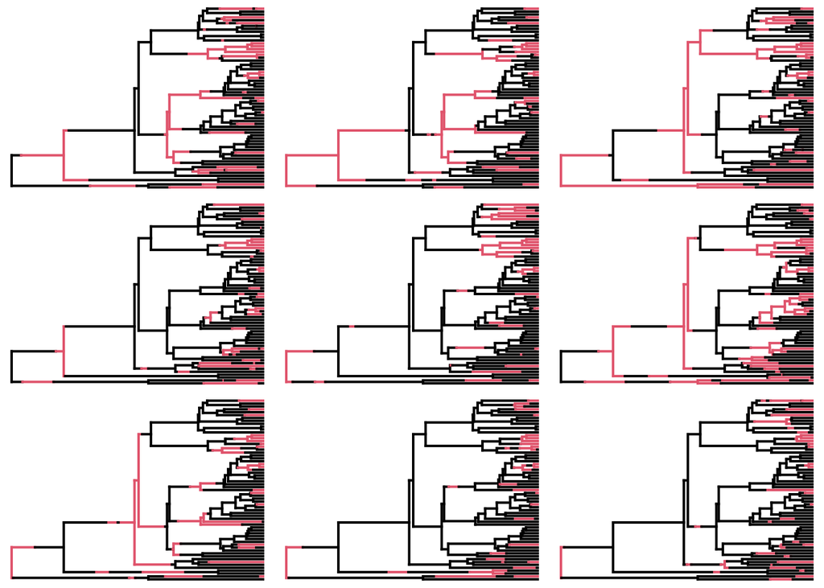

```r
par(mfrow=c(3,3), mar=c(0,0,0,0))
for(i in 1:9){
  plot(simmap[[i]], ftype="off")
}
```

### Continuous trait models

For continuous traits, we generally use “Gaussian models” that result in multivariate normal distributions. The most basic and familiar of these is Brownian motion. We can fit a Brownian motion model using the function `fitContinuous` from the `geiger` package.

```r
mBM <- fitContinuous(td2$phy, td2[['lnMass']], model="BM")
mBM
```

```
## GEIGER-fitted comparative model of continuous data
##  fitted 'BM' model parameters:
##  sigsq = 0.110338
##  z0 = 4.323551
##
##  model summary:
##  log-likelihood = -90.074247
##  AIC = 184.148495
##  AICc = 184.348495
##  free parameters = 2
##
## Convergence diagnostics:
##  optimization iterations = 100
##  failed iterations = 0
##  number of iterations with same best fit = 100
##  frequency of best fit = 1.00
##
##  object summary:
##  'lik' -- likelihood function
##  'bnd' -- bounds for likelihood search
##  'res' -- optimization iteration summary
##  'opt' -- maximum likelihood parameter estimates
```

An more general model than the Brownian motion model is the Ornstein-Uhlenbeck model, which has one additional parameter describing the central tendency of traits to evolve toward an intermediate optimum (think of a rubber band pulling back towards an optimum trait value).

```r
mOU <- fitContinuous(td2$phy, td2[['lnMass']], model="OU")
mBM
```

```
## GEIGER-fitted comparative model of continuous data
##  fitted 'BM' model parameters:
##  sigsq = 0.110338
##  z0 = 4.323551
##
##  model summary:
##  log-likelihood = -90.074247
##  AIC = 184.148495
##  AICc = 184.348495
##  free parameters = 2
##
## Convergence diagnostics:
##  optimization iterations = 100
##  failed iterations = 0
##  number of iterations with same best fit = 100
##  frequency of best fit = 1.00
##
##  object summary:
##  'lik' -- likelihood function
##  'bnd' -- bounds for likelihood search
##  'res' -- optimization iteration summary
##  'opt' -- maximum likelihood parameter estimates
```

Another model is one in which the rate of evolution is initially rapid, but slows over time. This is called the early-burst model (EB). Let’s fit all models simultaneously using a loop. This time, we’ll use the BMR data instead of the mass data:

```r
models <- c("BM", "OU", "EB")
mFits <- list()
for(i in 1:length(models)){
  mFits[[i]] <- fitContinuous(td2$phy, td2[['lnBMR']], model=models[i])
}
```

Model selection can be conducted by comparing AIC values:

```r
aiccs <- lapply(mFits, function(x) x$opt$aicc)
names(aiccs) <- models
aiccs
```

```
## $BM
## [1] 154.3445
##
## $OU
## [1] 150.447
##
## $EB
## [1] 156.5513
```

Which model did best? How do we interpret this?

## VI. Phylogenetic Regression

When we want to relate two traits to each other, we can make use of “Phylogenetic Generalized Least Squares Regression” or PGLS. This is equivalent to Independent Contrasts with Brownian Motion. The best package for using various types of this approach is `phylolm` written by Lam Ho, Cecile Ane, and others.

```r
rownames(td2$dat) <- td2$phy$tip.label
ols.lm1 <- lm(lnBMR ~ lnMass, data=td2$dat)
pgls.lm1 <- phylolm(lnBMR ~ lnMass, data=td2$dat, phy=td2$phy, model="BM")
summary(ols.lm1)
```

```
##
## Call:
## lm(formula = lnBMR ~ lnMass, data = td2$dat)
##
## Residuals:
##      Min       1Q   Median       3Q      Max
## -1.14946 -0.23248  0.05373  0.31112  0.59396
##
## Coefficients:
##             Estimate Std. Error t value Pr(>|t|)
## (Intercept)  1.34559    0.18135    7.42 4.39e-10 ***
## lnMass       0.72524    0.04331   16.75  < 2e-16 ***
## ---
## Signif. codes:  0 '***' 0.001 '**' 0.01 '*' 0.05 '.' 0.1 ' ' 1
##
## Residual standard error: 0.3832 on 61 degrees of freedom
## Multiple R-squared:  0.8213, Adjusted R-squared:  0.8184
## F-statistic: 280.4 on 1 and 61 DF,  p-value: < 2.2e-16
```

```r
summary(pgls.lm1)
```

```
##
## Call:
## phylolm(formula = lnBMR ~ lnMass, data = td2$dat, phy = td2$phy,
##     model = "BM")
##
##    AIC logLik
##  50.05 -22.03
##
## Raw residuals:
##      Min       1Q   Median       3Q      Max
## -1.12722 -0.19830  0.08083  0.33626  0.62233
##
## Mean tip height: 46.36958
## Parameter estimate(s) using ML:
## sigma2: 0.01272135
##
## Coefficients:
##             Estimate   StdErr t.value   p.value
## (Intercept) 1.369884 0.455064  3.0103  0.003792 **
## lnMass      0.711204 0.043475 16.3590 < 2.2e-16 ***
## ---
## Signif. codes:  0 '***' 0.001 '**' 0.01 '*' 0.05 '.' 0.1 ' ' 1
##
## R-squared: 0.8144    Adjusted R-squared: 0.8113
```

The results aren’t that different, in this case! Try a phylogenetic model with an interaction between desert and lnMass.

Check out the other models you can fit:

```r
?phylolm
```

These all have various assumptions, one in particular, the `lambda` transform, allows you to slide between an OLS and PGLS regression depending on the “Phylogenetic signal” measured in your data.

```r
lambda.lm <- phylolm(lnBMR ~ lnMass, data=td2$dat, phy=td2$phy, model="lambda")
summary(lambda.lm)
```

```
##
## Call:
## phylolm(formula = lnBMR ~ lnMass, data = td2$dat, phy = td2$phy,
##     model = "lambda")
##
##    AIC logLik
##  48.94 -20.47
##
## Raw residuals:
##      Min       1Q   Median       3Q      Max
## -1.12714 -0.19959  0.08204  0.33860  0.62383
##
## Mean tip height: 46.36958
## Parameter estimate(s) using ML:
## lambda : 0.9368721
## sigma2: 0.008279106
##
## Coefficients:
##             Estimate   StdErr t.value   p.value
## (Intercept) 1.380582 0.371935  3.7119 0.0004474 ***
## lnMass      0.707950 0.040953 17.2867 < 2.2e-16 ***
## ---
## Signif. codes:  0 '***' 0.001 '**' 0.01 '*' 0.05 '.' 0.1 ' ' 1
##
## R-squared: 0.8305    Adjusted R-squared: 0.8277
##
## Note: p-values and R-squared are conditional on lambda=0.9368721.
```

Let’s plot the results:

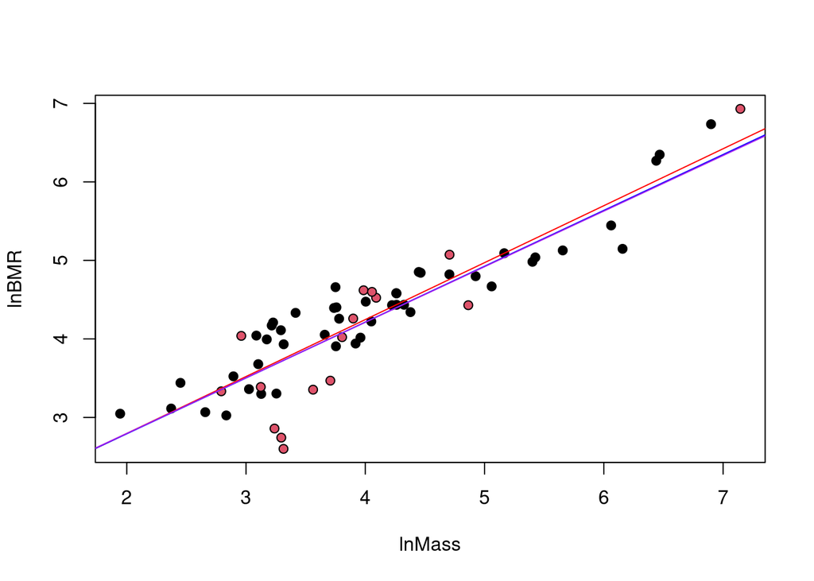

```r
plot(td2[['lnMass']], td2[['lnBMR']], xlab="lnMass", ylab="lnBMR", pch=21, bg=td2[['desert']]+1)
abline(ols.lm1, col="red")
abline(pgls.lm1, col="blue")
abline(lambda.lm, col="purple")
```

## VII. Getting a phylogeny from a list of taxa

Most comparative analyses require a time-calibrated phylogeny. The gold standard is to estimate this phylogeny from molecular sequence data, and time-calibrate the resulting phylogeny with fossil calibrations. However, some resources exist for drawing on existing phylogenetic and taxonomic information. One project spearheading the effort to synthesize existing phylogenetic knowledge is the OpenTree of Life (OTL) that has excellent API resources that can be used to obtain synthetic phylogenies, as well as other services such as taxonomic name resolution (this is huge, you will spend a huge amount of time dealing with names).

```r
taxalist <- c("Picoides_borealis", "Carpodacus_mexicana", "Hyla_regilla", "Lithobates_catesbeiana", "Cambarincola", "Cambarus_chasmodactylus", "Pipra_filicauda", "Chrysopelia_paradisi", "Norops_sagrei", "Carollia_perspicillata", "Piper peltatum", "Taeniopygia_guttata", "Plethodon_hubrichti", "Felus_domestica", "Aedes_aegypti", "Plasmodium_vivax")
```

Let’s use OpenTree of Life’s powerful taxonomic name resolution services, which draws on NCBI, GBIF, Fishbase, and others to build a comprehensive taxonomy for all life.

```r
ottTable <- tnrs_match_names(taxalist)
ottTable
```

| search_string | unique_name | approximate_match | ott_id | is_synonym | flags | number_matches |
| --- | --- | --- | --- | --- | --- | --- |
| picoides_borealis | Picoides borealis | TRUE | 701708 | FALSE | sibling_higher | 3 |
| carpodacus_mexicana | Haemorhous mexicanus | TRUE | 711865 | FALSE |  | 1 |
| hyla_regilla | Pseudacris regilla | TRUE | 1038213 | FALSE |  | 1 |
| lithobates_catesbeiana | Rana catesbeiana | TRUE | 14688 | FALSE |  | 3 |
| cambarincola | Cambarincola | FALSE | 251550 | FALSE | sibling_higher | 1 |
| cambarus_chasmodactylus | Cambarus chasmodactylus | TRUE | 1048056 | FALSE |  | 1 |
| pipra_filicauda | Pipra filicauda | TRUE | 946233 | FALSE |  | 1 |
| chrysopelia_paradisi | Chrysopelea paradisi | TRUE | 564756 | FALSE |  | 2 |
| norops_sagrei | Anolis sagrei | TRUE | 970153 | FALSE |  | 2 |
| carollia_perspicillata | Carollia perspicillata | TRUE | 1039980 | FALSE |  | 1 |

[output cut: 6 more lines]

Now we can use the Open Tree Taxonomy (OTT) IDs to obtain a synthetic tree of only those taxa.

```r
synth_tree <- tol_induced_subtree(ott_ids = ottTable$ott_id) #this one works, but doesn't provide valid dates.
```

[output not shown]

[output not shown]

[output cut: 61 more lines]

[output not shown]

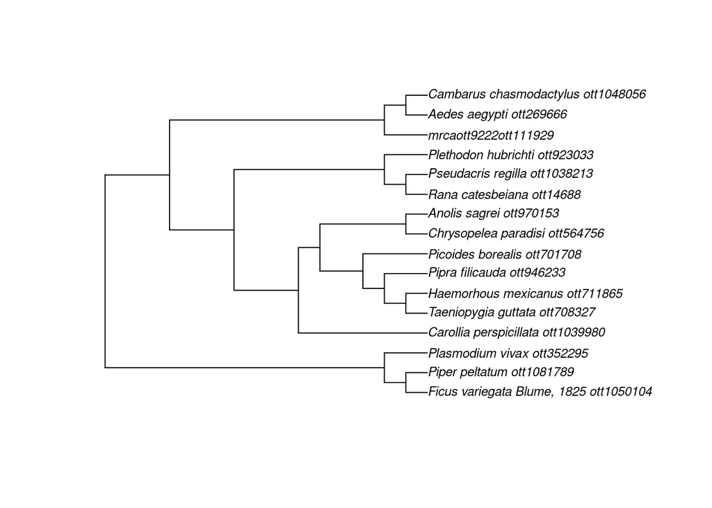

```r
plot(synth_tree, cex=0.75)
```